# Biostats week 4: Making great tables and graphs

# Outline

This packet reviews descriptive statistics and introduces options for making tables and graphs:

1. Descriptive statistics by variable types
2. Basic tables
3. Fancy tables
4. A new graphing option (and some code to make maps)

Packages used in this packet:

- tableone
- kableExtra
- waffle
- car
- ggplot2
- RNHANES
- maps (optional)
- mapproj (optional)
- htmltab (optional)

## Introduction

In this packet we will review descriptive statistics and learn to make great tables displaying these statistics. A new option for graphing will also be introduced.

The research questions we will answer with tables and graphs are:

- What are the characteristics of heroin and methamphetamine use among NHANES participants?
- What proportion of people in the US have ever used a gun?
- How do incarceration rates vary by state in the US?

First, use the `RNHANES`package to open the Drug Use survey:

```r
# open the RNHANES library
library(RNHANES)

# download 2013-2014 NHANES data
# use the name of the data you want (DUQ_H for drug use)
# add demographic data using demographics = TRUE
nhanes2013 <- nhanes_load_data(file_name = "DUQ_H",
                               year = "2013-2014",
                               demographics = TRUE)
```

## Descriptive statistics by variable types

- Continuous (or near continuous) variables
  - Use mean and standard deviation when normally distributed
  - Use median and IQR when skewed
- Categorical variables
  - Use frequency and percentage

## Data: heroin and methamphetamine use

*What are the characteristics of heroin and methamphetamine use among NHANES participants?*

There are several questions about heroin and meth use in the NHANES Drug Use questionnaire:

- Ever used heroin (DUQ290)
- Age first used heroin (DUQ300)
- Ever used methamphetamine (DUQ330)
- Age first used methamphetamine (DUQ340)

First, decide which descriptive statistics are useful for each variable. Categorical variables are straightforward since there is just one option: frequencies and percentages. Examine how the variables are coded in codebook and conduct some recoding to have logical variable names and logical category names:

```r
# open the car library to recode
library(car)

# recode DUQ290 to Yes, No, NA
# add a logical variable name
nhanes2013$ever.heroin <- recode(nhanes2013$DUQ290,
                                 "1 = 'Yes';
                                 2 = 'No';
                                 7 = NA;
                                 9 = NA")

# recode DUQ330 to Yes, No, NA
# add a logical variable name
nhanes2013$ever.meth <- recode(nhanes2013$DUQ330,
                                 "1 = 'Yes';
                                 2 = 'No';
                                 7 = NA;
                                 9 = NA")
```

Examine descriptive statistics for the categorical variables:

```r
# ever used frequencies
table(nhanes2013$ever.heroin)
```

```
##
##  No Yes
## 611 110
```

```r
table(nhanes2013$ever.meth)
```

```
##
##  No Yes
## 439 284
```

```r
# ever used percentages
prop.table(table(nhanes2013$ever.heroin))
```

```
##
##        No       Yes
## 0.8474341 0.1525659
```

```r
prop.table(table(nhanes2013$ever.meth))
```

```
##
##        No       Yes
## 0.6071923 0.3928077
```

Recode the continuous variables:

```r
# recode DUQ300 so out-of-range are NA
# add a logical variable name
nhanes2013$age.first.heroin <- recode(nhanes2013$DUQ300,
                                 "777 = NA;
                                 999 = NA")

# recode DUQ340 so out-of-range are NA
# add a logical variable name
nhanes2013$age.first.meth <- recode(nhanes2013$DUQ340,
                                 "777 = NA;
                                 999 = NA")
```

Descriptives for continuous:

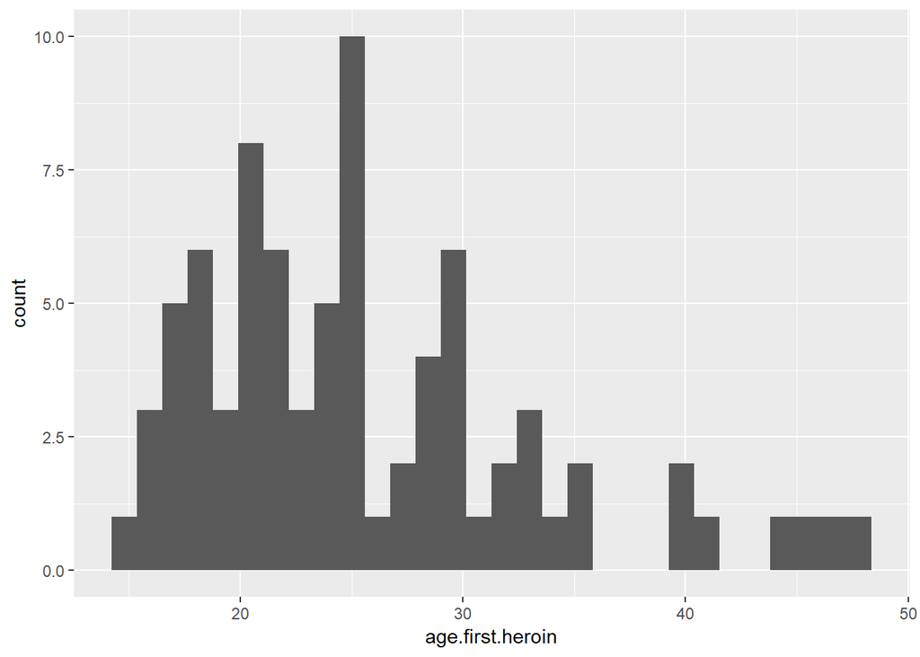

```r
# are they normally distributed?
library(ggplot2)
ggplot(data = nhanes2013, aes(x = age.first.heroin)) +
  geom_histogram()
```

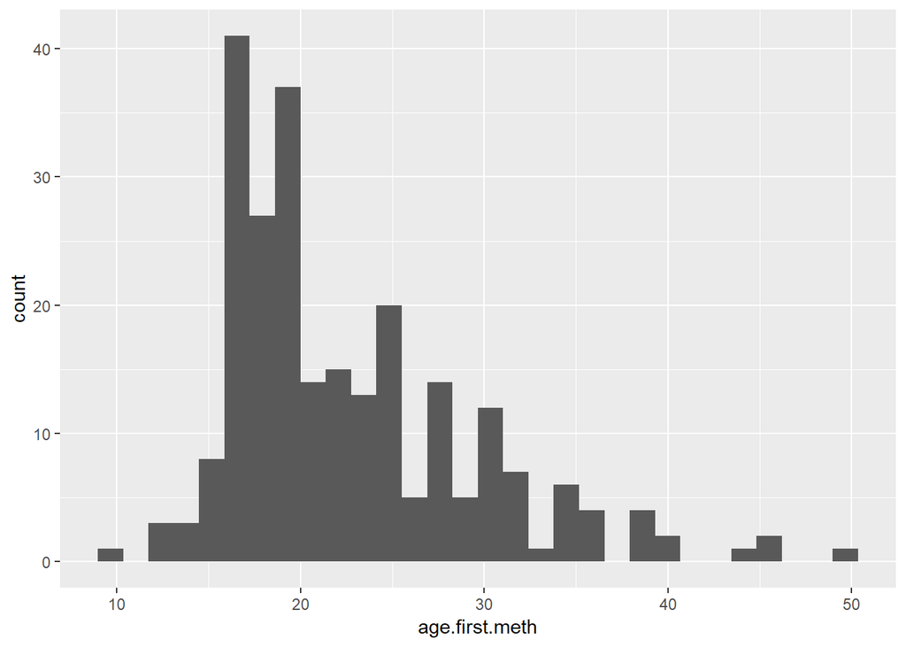

```r
ggplot(data = nhanes2013, aes(x = age.first.meth)) +
  geom_histogram()
```

```r
# plots looks skewed right, use median & IQR
median(nhanes2013$age.first.heroin, na.rm = TRUE)
```

```
## [1] 24
```

```r
median(nhanes2013$age.first.meth, na.rm = TRUE)
```

```
## [1] 21
```

```r
IQR(nhanes2013$age.first.heroin, na.rm = TRUE)
```

```
## [1] 10
```

```r
IQR(nhanes2013$age.first.meth, na.rm = TRUE)
```

```
## [1] 8
```

Great! We have all the descriptive statistics! How can we put it all in a well-formatted table?

Clear tables tend to have the following features:

- A title that explains what is in the table
  - The number of observations if possible
  - The year the data were collected if possible
  - The units of measurement (people, organizations, etc)
- Consistent use of the same number of decimal places throughout the table
- Numbers aligned to the right so that the decimal points line up
- Words aligned to the left
- Indentation and shading to differentiate rows or sections
- Limited internal lines
- Clearly labelled rows and columns

## Basic table in R

We could open a word processing document and copy the numbers from the R output above for each variable (median, IQR, etc.) into the document to make a table. However, there are (at least) three reasons this is not a great strategy:

1. Transcribing the numbers can (and does) result in errors
2. Changes to table contents can be made more easily
3. R code can be reused, so developing new tables will take less time after the first one is complete

Let’s start with a very basic table for the heroin and meth variables we have cleaned. If you do not need the table to be formatted in a fancy way for a paper or something else, the `tableone` package has a very clear interface for getting descriptive statistics into a table format easily. Try it with the clean variables:

```r
# open tableone package
library(tableone)

# create table from all variables
drug.table <- CreateTableOne(vars = c('age.first.heroin',
                                      'age.first.meth',
                                      'ever.heroin',
                                      'ever.meth'), data = nhanes2013)

# print out table basic
print(drug.table)
```

```
##
##                                Overall
##   n                             5057
##   age.first.heroin (mean (sd)) 25.66 (7.65)
##   age.first.meth (mean (sd))   22.68 (6.74)
##   ever.heroin = Yes (%)          110 (15.3)
##   ever.meth = Yes (%)            284 (39.3)
```

This looks good, although we decided that the age variables were not normally distributed, so the median and IQR are more appropriate to report. The print feature of the `tableone` package has options for identifying non-normal variables:

```r
# indicate which variables are non-normal
# add argument to print every category of categorical
print(drug.table, nonnormal = c('age.first.meth', 'age.first.heroin'),
      showAllLevels = TRUE)
```

```
##
##                                   level Overall
##   n                                      5057
##   age.first.heroin (median [IQR])       24.00 [20.00, 30.00]
##   age.first.meth (median [IQR])         21.00 [18.00, 26.00]
##   ever.heroin (%)                 No      611 (84.7)
##                                   Yes     110 (15.3)
##   ever.meth (%)                   No      439 (60.7)
##                                   Yes     284 (39.3)
```

This is really nice for exploring the data and could be copied and pasted easily into Word or Excel for formatting. You might even use it rather than running means, standard deviations, frequencies, and percentages separately. The next option is **more difficult** to use but allows you to make a well-formatted table that can be directly used in a report or paper.

## Fancy table in R

The `kable` package takes descriptive statistics (not raw data) and allows a lot of formatting to make publication-ready tables, like this:

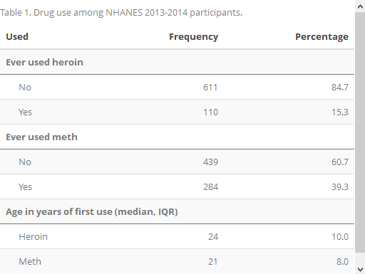

But first the data must be in a clean data frame of descriptive statistics (not raw data!) with all the right labels. For example, the information we got above from all the descriptive statistics commands should be organized into a data frame like this:

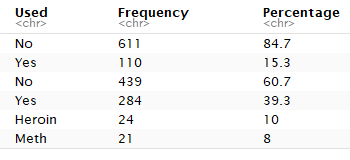

To do this we will combine the descriptive information from each of the variables into a data frame of descriptive statistics.

First, combine the frequency and percentage tables for heroin use. The `cbind` command combines them by columns (`rbind` would combine by row).

```r
# descriptives for heroin use
heroin.use <- cbind(table(nhanes2013$ever.heroin),
                    prop.table(table(nhanes2013$ever.heroin)))
heroin.use
```

```
##     [,1]      [,2]
## No   611 0.8474341
## Yes  110 0.1525659
```

Two problems:

- There are no variable names on the columns
- The percentage needs to be cleaned up

Add variable names of Frequency and Percentage, fix the percentages, and make it a data frame:

```r
# percentages multiplied by 100
heroin.use <- cbind(Frequency = table(nhanes2013$ever.heroin),
                    Percentage = 100*(prop.table(table(nhanes2013$ever.heroin))))
heroin.use
```

```
##     Frequency Percentage
## No        611   84.74341
## Yes       110   15.25659
```

Now, change it to a data frame:

```r
# make data frame
heroin.use <- data.frame(heroin.use)
```

Make meth:

```r
# percentages multiplied by 100
meth.use <- cbind(Frequency = table(nhanes2013$ever.meth),
                  Percentage = 100*(prop.table(table(nhanes2013$ever.meth))))

# make data frame
meth.use <- data.frame(meth.use)
```

Combine heroin and meth data frames:

```r
# combine data frames
drug.use <- rbind(usedHeroin = heroin.use, usedMeth = meth.use)
drug.use
```

```
##                Frequency Percentage
## usedHeroin.No        611   84.74341
## usedHeroin.Yes       110   15.25659
## usedMeth.No          439   60.71923
## usedMeth.Yes         284   39.28077
```

Now that we have a clean data frame with descriptive statistics in it, try a `kable` table. Notice the `%>%` in the table command. This is a pipe. Pipes send information from one command to another without saving any of the intermediate steps. Think of them like a pipe in your home that sends water from one place to another.

```r
# open library for making tables
library(kableExtra)

# make basic table with styling so it shows up
kable(drug.use, "html", caption = "Drug Use among NHANES 2013-2014 participants") %>%
  kable_styling("striped", full_width = TRUE)
```

Drug Use among NHANES 2013-2014 participants

|  | Frequency | Percentage |
| --- | --- | --- |
| usedHeroin.No | 611 | 84.74341 |
| usedHeroin.Yes | 110 | 15.25659 |
| usedMeth.No | 439 | 60.71923 |
| usedMeth.Yes | 284 | 39.28077 |

The table is pretty basic and not really much better than the `tableone` version at this point, but we have only just begun! Next we will add the continuous variables and then group and label sections of the table.

```r
# make vectors of the median and IQR for
# age meth use and age heroin use
age.heroin.desc <- c(median(nhanes2013$age.first.heroin, na.rm = T),
                  IQR(nhanes2013$age.first.heroin, na.rm = T))
age.heroin.desc
```

```
## [1] 24 10
```

```r
age.meth.desc <- c(median(nhanes2013$age.first.meth, na.rm = T),
                  IQR(nhanes2013$age.first.meth, na.rm = T))
age.meth.desc
```

```
## [1] 21  8
```

We now have two vectors with the medians and IQR for heroin and meth use. Use the `rbind`, or row bind, command to add them to the `drug.use` data frame:

```r
# add vectors as rows to the drug.use data frame
drug.use.all <- rbind(drug.use, ageHeroin = age.heroin.desc,
                      ageMeth = age.meth.desc)

# print the data frame to check it
drug.use.all
```

```
##                Frequency Percentage
## usedHeroin.No        611   84.74341
## usedHeroin.Yes       110   15.25659
## usedMeth.No          439   60.71923
## usedMeth.Yes         284   39.28077
## ageHeroin             24   10.00000
## ageMeth               21    8.00000
```

Try with the `kable` formatting:

```r
# make basic table with styling so it shows up
kable(drug.use.all, "html", caption = "Drug Use among NHANES 2013-2014 participants",
      digits = 1) %>%
  kable_styling("striped", full_width = TRUE)
```

Drug Use among NHANES 2013-2014 participants

|  | Frequency | Percentage |
| --- | --- | --- |
| usedHeroin.No | 611 | 84.7 |
| usedHeroin.Yes | 110 | 15.3 |
| usedMeth.No | 439 | 60.7 |
| usedMeth.Yes | 284 | 39.3 |
| ageHeroin | 24 | 10.0 |
| ageMeth | 21 | 8.0 |

Well, it almost worked! The row names are not ideal for labels in the table. Add a new variable that will make better labels for the rows:

```r
# make a new variable to label rows better
Used <- c("No", "Yes", "No", "Yes", "Heroin", "Meth")

# add never variable as a column to the data frame
drug.use.all.labelled <- cbind(Used, drug.use.all)

# print the data frame to check it
drug.use.all.labelled
```

```
##                  Used Frequency Percentage
## usedHeroin.No      No       611   84.74341
## usedHeroin.Yes    Yes       110   15.25659
## usedMeth.No        No       439   60.71923
## usedMeth.Yes      Yes       284   39.28077
## ageHeroin      Heroin        24   10.00000
## ageMeth          Meth        21    8.00000
```

Try it again with `kable`, removing the row.names:

```r
# table with all four variables
kable(drug.use.all.labelled, "html", caption = "Table 1. Drug use among NHANES 2013-2014 participants.", row.names = FALSE, digits = 1) %>%
  kable_styling("striped", full_width = TRUE)
```

Table 1. Drug use among NHANES 2013-2014 participants.

| Used | Frequency | Percentage |
| --- | --- | --- |
| No | 611 | 84.7 |
| Yes | 110 | 15.3 |
| No | 439 | 60.7 |
| Yes | 284 | 39.3 |
| Heroin | 24 | 10.0 |
| Meth | 21 | 8.0 |

It has all the numbers we need. The new row labels are good. However, it needs a way to differentiate heroin and meth used for the first four rows. It also needs to say median and IQR for the Heroin and Meth rows at the bottom. The `kable` group_rows option does this:

```r
# table with all four variables
kable(drug.use.all.labelled, "html", caption = "Table 1. Drug use among NHANES 2013-2014 participants.", row.names = FALSE, digits = 1) %>%
  kable_styling("striped", full_width = TRUE) %>%
  group_rows("Ever used heroin", 1, 2) %>%
  group_rows("Ever used meth", 3, 4) %>%
  group_rows("Age in years of first use (median, IQR)", 5, 6)
```

Table 1. Drug use among NHANES 2013-2014 participants.

| Used | Frequency | Percentage |
| --- | --- | --- |
| **Ever used heroin** |  |  |
| No | 611 | 84.7 |
| Yes | 110 | 15.3 |
| **Ever used meth** |  |  |
| No | 439 | 60.7 |
| Yes | 284 | 39.3 |
| **Age in years of first use (median, IQR)** |  |  |
| Heroin | 24 | 10.0 |
| Meth | 21 | 8.0 |

Ok! That looks ready to put in a paper or on a website. Here is a summary of the relevant code:

```r
# categorical variables vectors
heroin.use <- cbind(Frequency = table(nhanes2013$ever.heroin),
                    Percentage = 100*(prop.table(table(nhanes2013$ever.heroin))))
meth.use <- cbind(Frequency = table(nhanes2013$ever.meth),
                  Percentage = 100*(prop.table(table(nhanes2013$ever.meth))))

# make categorical variables into data frames and combine
meth.use <- data.frame(meth.use)
heroin.use <- data.frame(heroin.use)
drug.use <- rbind(usedHeroin = heroin.use, usedMeth = meth.use)

# continuous variables vectors
age.heroin.desc <- c(median(nhanes2013$age.first.heroin, na.rm = T),
                  IQR(nhanes2013$age.first.heroin, na.rm = T))
age.meth.desc <- c(median(nhanes2013$age.first.meth, na.rm = T),
                  IQR(nhanes2013$age.first.meth, na.rm = T))

# add continuous variables to drug.use data frame
drug.use.all <- rbind(drug.use, ageHeroin = age.heroin.desc,
                      ageMeth = age.meth.desc)

# make a new variable to name the rows better and add to data frame
Used <- c("No", "Yes", "No", "Yes", "Heroin", "Meth")
drug.use.all.labelled <- cbind(Used, drug.use.all)

# make the table
kable(drug.use.all.labelled, "html", caption = "Table 1. Drug use among NHANES 2013-2014 participants.", row.names = FALSE, digits = 1) %>%
  kable_styling("striped", full_width = TRUE) %>%
  group_rows("Ever used heroin", 1, 2) %>%
  group_rows("Ever used meth", 3, 4) %>%
  group_rows("Age in years of first use (median, IQR)", 5, 6)
```

Table 1. Drug use among NHANES 2013-2014 participants.

| Used | Frequency | Percentage |
| --- | --- | --- |
| **Ever used heroin** |  |  |
| No | 611 | 84.7 |
| Yes | 110 | 15.3 |
| **Ever used meth** |  |  |
| No | 439 | 60.7 |
| Yes | 284 | 39.3 |
| **Age in years of first use (median, IQR)** |  |  |
| Heroin | 24 | 10.0 |
| Meth | 21 | 8.0 |

There are lots of things you can do with `kable` to style and save your table. Use the Google to see what is out there.

## A new graphing option (and some code to make maps)

In past weeks we have used:

- histograms and density plots to understand one continuous variable
- bar graphs to understand one or two categorical variables
- mosaic plots to understand two categorical variables together
- box plots and petal plots to understand categorical and continuous variables together
- scatterplots for two continuous variables together

This section offers one more option (and some code for maps):

- waffle plot to understand a single categorical variable

## Waffle plots

Pie charts are meant to show parts of a whole. The pie, or circle, represents the whole.The slices of pie shown in different colors represent the parts. While pie charts are often seen in newspapers and other popular media, they are considered by most analysts as an unclear way to display data. A few of the reasons for this were summarized in an R-bloggers post: https://www.r-bloggers.com/pie-charts-in-ggplot2/. In fact, if you asked 100 analysts, “Should I make a pie graph?”, they might answer:

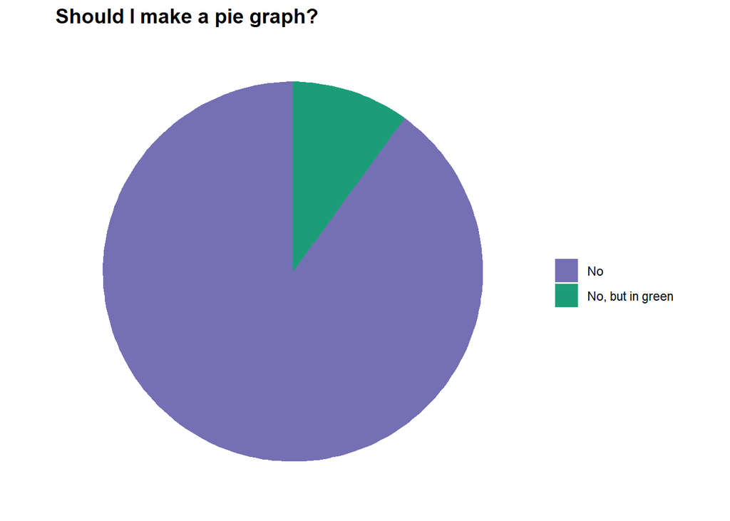

Instead, a waffle plot shows parts of a whole in a way that allows more clear interpretation (**waffles > pie**). Let’s use the gun use question in the 2011-2012 NHANES audiology questionnaire: *Ever used firearms for any reason?*

The code book is here: https://wwwn.cdc.gov/nchs/nhanes/2011-2012/AUQ_G.htm

The question is AUQ300.

Bring in the data and do a little data management to add labels first, then make a waffle:

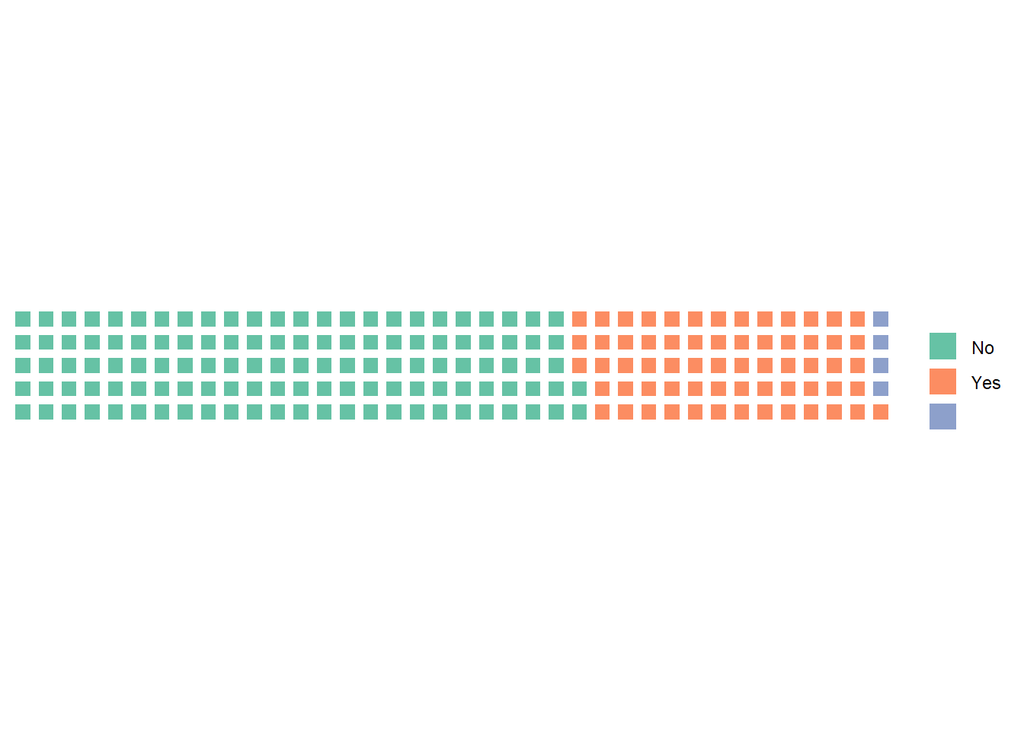

```r
# load the 2011-2012 data
nhanes2011 <- nhanes_load_data("AUQ_G", "2011-2012", demographics = TRUE)

# recode gun use variable
nhanes2011$gunUse <- recode(nhanes2011$AUQ300,
                              "1 = 'Yes';
                            2 = 'No';
                            7 = NA")

# open library and make graph
# each square is 25 people
# 5 rows of squares
library(waffle)
waffle(table(nhanes2011$gunUse)/25, rows=5)
```

Hm. There seems to be an extra color and it is missing a title. **Waffle plot was written for 3 or more groups, so with 2 groups there is an extra blank color, use white to make it disappear.** The same problem will not happen if there are 3 or more groups.

The squares could also be bigger to hold more people. The waffle plot can be customized to use whatever colors you like. Check colorbrewer2.org for ideas on colors to use. Here is one option using some colorbrewer colors and white to hide the extra group:

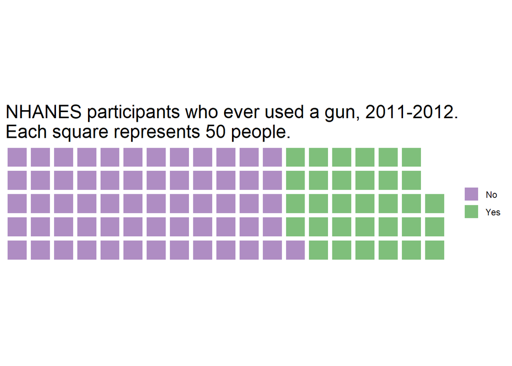

```r
#add a title
#change the colors
waffle(table(nhanes2011$gunUse)/50, rows=5,
       title = "NHANES participants who ever used a gun, 2011-2012.\nEach square represents 50 people.",
       colors = c("#af8dc3", "#7fbf7b", "white"))
```

## Making a map to display data (just FYI)

The `ggplot2` package has a geom for mapping. It can take global, state, or county-level data. The map below demonstrates the use of the `geom_map` with state-level incarceration data in from Wikipedia. The `htmltab` package can bring in data from online tables.

The map feature in `ggplot2` relies on two variables: (1) a variable named `region` with state names in all-lower case letters, (2) a numeric or factor variable of something you want to map.

```r
# LOAD THE DATA

# use htmltab package to bring in data from a website
# incarceration rate by state in 2016
library(htmltab)

# the URL where the data are
incarcerationURL <- "https://en.wikipedia.org/wiki/List_of_U.S._states_by_incarceration_and_correctional_supervision_rate"

# naming the data frame
prison.rate <- htmltab(doc = incarcerationURL, header = 1, which = 3)
prison.rate2016 <- prison.rate[c(4:56), c(1,3)]
names(prison.rate2016) <- c("region", "prison.per100k")

# state map takes lower case version of state
# change the region variable to lower case
prison.rate2016$region <- tolower(prison.rate2016$region)

# make prison.per100k numeric after removing commas
prison.rate2016$prison.per100k <- as.numeric(gsub(",", "", prison.rate2016$prison.per100k))

# load in the basic US state map information from the ggplot2 package
# here it is being named "us"
us <- map_data("state")
```

Once the data are formatted with:

- region variable of state names in all lower case
- numeric or factor variable to map for each state

Build the map, like this:

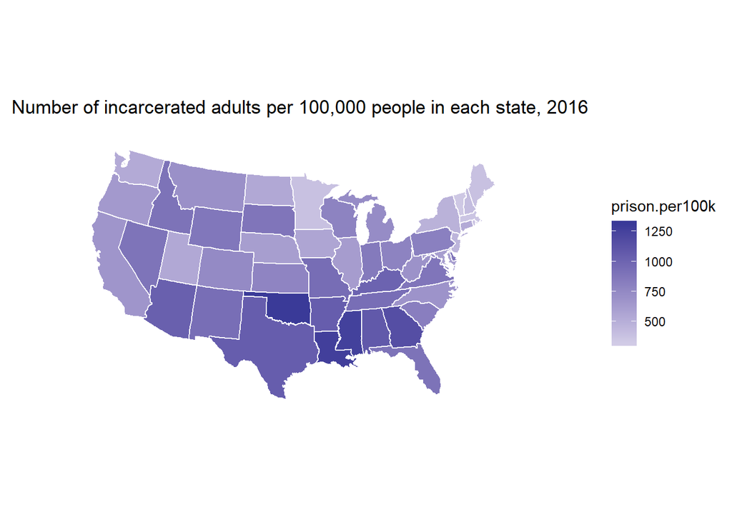

```r
# MAKE THE MAP

# basic stuff for all state maps
ggplot() +
  geom_map(data = us, map = us, aes(x = long, y = lat,
                        map_id = region)) +

# add the variable of interest to the map
  geom_map(data = prison.rate2016, map = us,
                    aes(fill = prison.per100k, map_id = region),
                    color="#ffffff") +

# tell R to use a gradient to shade from low to high
# can add colors for high and low if preferred
  scale_fill_gradient2() +

# remove labels on x and y axes
  labs(x=NULL, y=NULL) +

# use albers coordinate system that makes the map look nice
# see different coordinate systems to choose from here:
# https://stackoverflow.com/questions/31216951/how-do-i-change-the-projection-method-used-by-r-for-mapping-coordinates
  coord_map("albers", lat0 = 39, lat1 = 45) +

# remove all the regular stuff a ggplot has by making it all blank
  theme(panel.border = element_blank(), panel.background = element_blank(),
                           axis.ticks = element_blank(), axis.text = element_blank()) +

# add a relvant title
  ggtitle("Number of incarcerated adults per 100,000 people in each state, 2016")
```

## Challenge 4

Pick the standard or hacker challenge RMD file from GitHub. Write the code and text needed to answer the questions. Submit the RMD file (not the knit file) via Blackboard before the next class meeting.